# 🛒 Shop Data Explorer – End-to-End Data Engineering & Analytics App

## 🎯 Project Goal

**Shop Data Explorer** is an interactive analytics application that simulates a retail sales environment.  
It was built to demonstrate an **end-to-end pipeline**: from raw data with inconsistencies → through ETL in Python & SQL → to clean, structured datasets → to business insights presented in dashboards.

The goal was to practice **Data Engineering concepts** (ETL, SQL query building, Python pipelines, cleaning) while also adding **Data Analytics & Visualization** layers for business users.

## 🧰 Technologies and Tools

| Category | Technology | Purpose |
| --- | --- | --- |
| Database | `SQLite` | Simulated transactional database |
| Backend / ETL | `Python`, `pandas` | Data extraction, cleaning, transformation |
| Query Layer | `SQL` | Dynamic query building & aggregation |
| Visualization | `Streamlit`, `Seaborn`, `Matplotlib`, `HTML/CSS`, `Plotly` | Interactive dashboards & custom leaderboards |
| Version Control | `GitHub` | Code versioning and documentation |

## 🗃️ Database Creation

The database was created **from scratch** to simulate real-world messy data:

- **Inconsistent category names** (e.g. "electronics" vs "Electronics" vs "elektronika")
- **Country mismatches** (e.g. "PL", "Polska", "Poland")
- **Missing values** in customers and orders
- **Fake nulls** (`"null"`, `"none"`, empty strings)

➡️ This design forced the ETL pipeline to handle cleaning, mapping, and transformation, just like in real business systems.

🗃️UML diagram of the database schema:

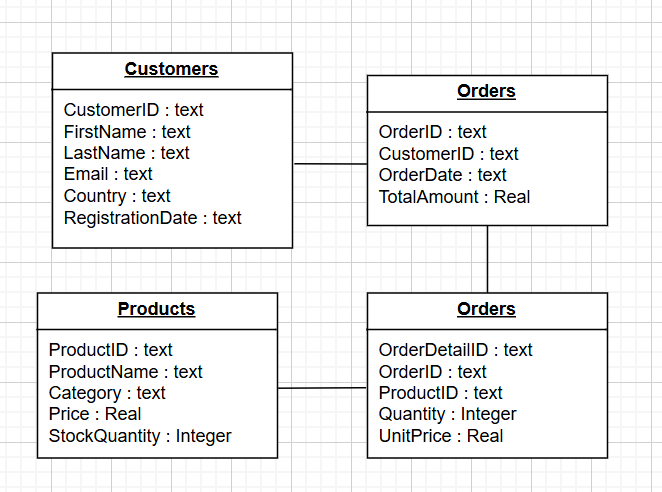

## 📊 Visualization Section

### 1. 🥇 Top Performance Mode

This mode shows leaderboards of **best or worst performing entities**, filtered by year:

- Top Customers
- Top Products
- Top Categories
- Top Months
- Top Countries

Each leaderboard is generated dynamically with **SQL CTE queries**, cleaned in Python, and rendered in **Streamlit with custom HTML badges** (🥇 🥈 🥉 🚫 📉).

### 📸 Customers – Best in Sales Over the Years (Leaderboard)

Leaderboard ranking customers by **total sales per year**, calculated with SQL window functions and visualized in Streamlit with custom HTML badges 🥇🥈🥉.

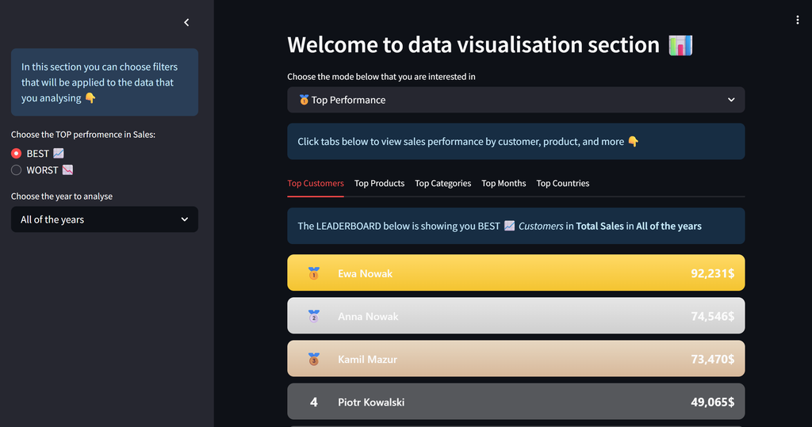

### 📸 Screenshot: Products that have been selling the Best over the Years (Leaderboard)

This leaderboard dynamically ranks products based on **total sales per year**, using SQL CTEs and window functions.  
It is then cleaned in Python (pandas) and displayed in Streamlit with custom HTML badges 🥇🥈🥉.

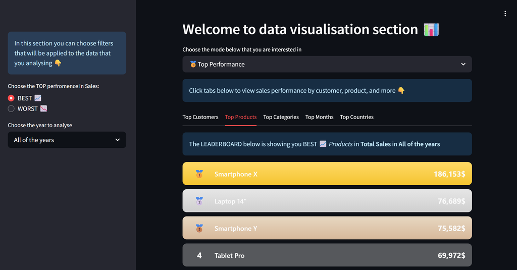

### 📸 Screenshot: Months that had worst selling scores in 2024 (Leaderboard)

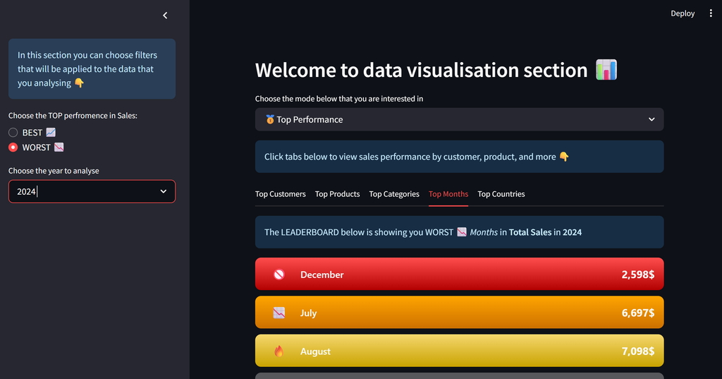

### 2. 🔍 Deep Dive: Client (Work in progress)

This mode allows a detailed look into a **single customer’s activity**:

- Monthly sales trends (total and average)
- Categories purchased by the client
- Product purchase breakdown

### 📸 Monthly Sales Overview – Adam Zielony

This chart shows **monthly total and average sales** for the customer *Adam Zielony*.  
Data is extracted using a **SQL CTE**, aggregated by month, and then cleaned in Python:

```
WITH CustomerMonthlySales AS (
    SELECT
        strftime('%Y', o.OrderDate) AS OrderYear,
        strftime('%m', o.OrderDate) AS Month,
        SUM(od.UnitPrice * od.Quantity) AS TotalSales,
        AVG(od.UnitPrice * od.Quantity) AS AvgSales
    FROM Customers c
    JOIN Orders o ON c.CustomerID = o.CustomerID
    JOIN OrderDetails od ON od.OrderID = o.OrderID
    WHERE CONCAT(c.FirstName, ' ', c.LastName) = 'Adam Zielony'
    GROUP BY OrderYear, Month
)
SELECT * FROM CustomerMonthlySales;
```

📸 Monthly Sales Overview – Adam Zielony (screanshot):

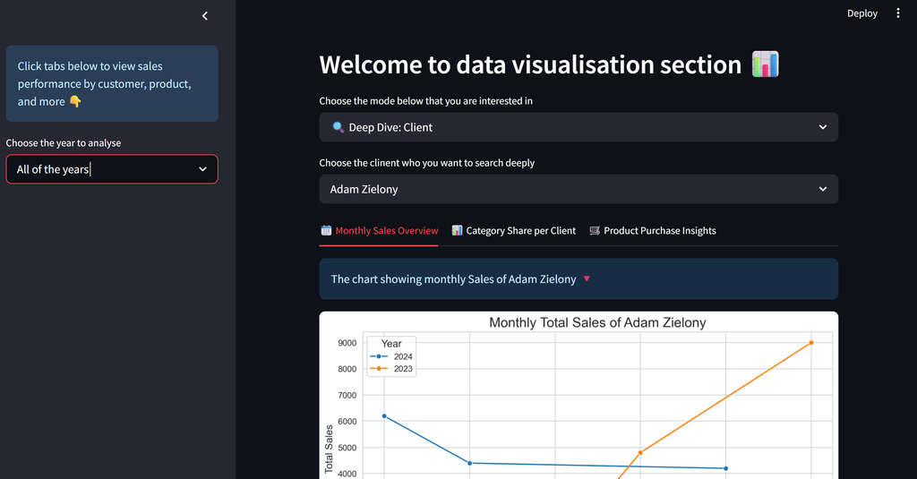

### 3. 📦 Product Insights (Work in Progress)

A new module for analyzing product-level performance in more detail:

- Cross-year product comparisons
- Price and sales evolution
- Category-product breakdowns

## 🚀 Possible Updates & Improvements

- 🌐 Deployment of the app in the cloud (Streamlit Cloud or DigitalOcean VPS)
- 🗄️ Migrating from SQLite → **PostgreSQL on AWS RDS / Azure SQL**
- ☁️ Using **cloud storage (AWS S3, Azure Blob)** for input data instead of local DB
- 🔄 Automating ETL jobs with **Apache Airflow / Prefect**
- 🧩 Integrating external data sources (e.g. fetching datasets via Python API or SAP connectors)
- 📦 Expanding Product Insights with advanced visualizations (time-series, cohort analysis, cross-sell analysis)
- 🛠️ Adding **unit tests & data validation** with `pytest` or `Great Expectations`
- 🔐 Handling **data security and access control** (roles, masking sensitive fields)
- ⚡ Scaling ETL pipelines with **PySpark** for distributed data processing
- 🔄 Migrating transformations from pandas → PySpark DataFrames for larger datasets
- 🏗️ Testing Spark SQL alongside SQLAlchemy queries for performance comparison

## 🧠 What I Learned

- 🗄️ Designing a database schema with **realistic dirty data**
- 🐍 Building **dynamic SQL query builders** in Python (`SELECT`, `WHERE`, filters)
- ⚙️ Implementing **ETL pipelines** (cleaning, mapping, joining multiple tables)
- 📊 Ranking with SQL `RANK() OVER` and aggregations
- 🎨 Creating **interactive dashboards** in Streamlit with custom HTML & CSS
- 🚀 Applying a **Data Engineering mindset**: structured, reusable, scalable solutions

## 🎯 For Recruiter

This project proves I can deliver an **end-to-end data solution**:

- 🗃️ From raw, inconsistent data
- ⚙️ Through SQL + Python ETL pipelines
- 📊 To clean dashboards in Streamlit

➡️ Core skills: **SQL | Python (pandas) | ETL | Streamlit | Data Visualization**